# DS 621 Fall2020: Homework 3 (Group3)

Crime Logistic Regression

Zach Alexander, Sam Bellows, Donny Lofland, Joshua Registe, Neil Shah, Aaron Zalki

Source code: https://github.com/djlofland/DS621_F2020_Group3/tree/master/Homework_3

## Instructions

### Overview

In this homework assignment, you will explore, analyze, and model a data set containing information on crime for various neighborhoods of a major city. Each record has a response variable indicating whether or not the crime rate is above the median crime rate (1) or not (0).

Your objective is to build a binary logistic regression model on the training data set to predict whether the neighborhood will be at risk for high crime levels. You will provide classifications and probabilities for the evaluation data set using your binary logistic regression model. You can only use the variables given to you (or variables that you derive from the variables provided). Below is a short description of the variables of interest in the data set:

- `zn`: the proportion of residential land zoned for large lots (over 25000 square feet) (predictor variable)
- `indus`: the proportion of non-retail business acres per suburb (predictor variable)
- `chas`: a dummy var. for whether the suburb borders the Charles River (1) or not (0) (predictor variable)
- `nox`: nitrogen oxides concentration (parts per 10 million) (predictor variable)
- `rm`: average number of rooms per dwelling (predictor variable)
- `age`: the proportion of owner-occupied units built prior to 1940 (predictor variable)
- `dis`: weighted mean of distances to five Boston employment centers (predictor variable)
- `rad`: index of accessibility to radial highways (predictor variable)
- `tax`: full-value property-tax rate per $10,000 (predictor variable)
- `ptratio`: pupil-teacher ratio by town (predictor variable)
- `lstat`: lower status of the population (percent) (predictor variable)
- `medv`: median value of owner-occupied homes in $1000s (predictor variable)
- `target`: whether the crime rate is above the median crime rate (1) or not (0) (response variable)

### Deliverables

- A write-up submitted in PDF format. Your write-up should have four sections. Each one is described below. You may assume you are addressing me as a fellow data scientist, so do not need to shy away from technical details.
- Assigned prediction (probabilities, classifications) for the evaluation data set. Use a 0.5 threshold.
- Include your R statistical programming code in an Appendix.

## Introduction

Crime is a common concern in large cities, and denizens, policymakers, and law enforcement are interested in identifying locations where crime can or might occur. In this assignment, we are given a dataset for the city of Boston and will build a model to identify regions that might have higher or lower (against the median) crime. Since the goal is a binary (above or below median) response, this assignment will employ binary logistic regression–and will not be predicting an actual value, like the Moneyball assignment.

## 1. Data Exploration

*Describe the size and the variables in the crime training data set. Consider that too much detail will cause a manager to lose interest while too little detail will make the manager consider that you aren’t doing your job. Some suggestions are given below. Please do NOT treat this as a checklist of things to do to complete the assignment. You should have your own thoughts on what to tell the boss. These are just ideas.*

### Dataset

The dataset is notably different from Assignment 1’s Moneyball regression dataset in two ways: It contains both a categorical target and provides some categorical features. The fact that we are provided with a categorical target turns the task from a regression task to a classification task, perfect for logistic regression. The data contains 12 features and 466 instances, with 40 instances reserved for an evaluation dataset with targets removed.

There are two files provided:

- **crime-training-data_modified.csv** - hold data from training a model
- **crime-evaluation-data_modified.csv** - holdout data used for evaluation. Note this dataset doesn’t include the target column so while we can predict classes, our model will have to be scored by an outside group with knowledge of the actual classes.

Below, we created a chart that describes each variable in the dataset and the theoretical effect it will have on the crime rate.

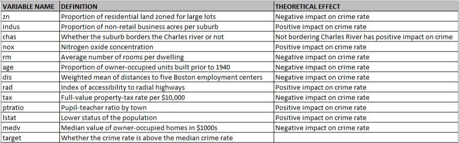

Variables of Interest

### Summary Stats

We compiled summary statistics on our dataset to better understand the data before modeling.

```
##        zn             indus             chas              nox
##  Min.   :  0.00   Min.   : 0.460   Min.   :0.00000   Min.   :0.3890
##  1st Qu.:  0.00   1st Qu.: 5.145   1st Qu.:0.00000   1st Qu.:0.4480
##  Median :  0.00   Median : 9.690   Median :0.00000   Median :0.5380
##  Mean   : 11.58   Mean   :11.105   Mean   :0.07082   Mean   :0.5543
##  3rd Qu.: 16.25   3rd Qu.:18.100   3rd Qu.:0.00000   3rd Qu.:0.6240
##  Max.   :100.00   Max.   :27.740   Max.   :1.00000   Max.   :0.8710
##        rm             age              dis              rad
##  Min.   :3.863   Min.   :  2.90   Min.   : 1.130   Min.   : 1.00
##  1st Qu.:5.887   1st Qu.: 43.88   1st Qu.: 2.101   1st Qu.: 4.00
##  Median :6.210   Median : 77.15   Median : 3.191   Median : 5.00
##  Mean   :6.291   Mean   : 68.37   Mean   : 3.796   Mean   : 9.53
##  3rd Qu.:6.630   3rd Qu.: 94.10   3rd Qu.: 5.215   3rd Qu.:24.00
##  Max.   :8.780   Max.   :100.00   Max.   :12.127   Max.   :24.00
##       tax           ptratio         lstat             medv
##  Min.   :187.0   Min.   :12.6   Min.   : 1.730   Min.   : 5.00
##  1st Qu.:281.0   1st Qu.:16.9   1st Qu.: 7.043   1st Qu.:17.02
##  Median :334.5   Median :18.9   Median :11.350   Median :21.20
##  Mean   :409.5   Mean   :18.4   Mean   :12.631   Mean   :22.59
##  3rd Qu.:666.0   3rd Qu.:20.2   3rd Qu.:16.930   3rd Qu.:25.00
##  Max.   :711.0   Max.   :22.0   Max.   :37.970   Max.   :50.00
##      target
##  Min.   :0.0000
##  1st Qu.:0.0000
##  Median :0.0000
##  Mean   :0.4914
##  3rd Qu.:1.0000
##  Max.   :1.0000
```

The first observation is that we have no missing data (coded as NA’s).

Based on the summary statistics, it appears we have some highly skewed features, as many features have means that are far from the median indicating a skewed distribution. Some examples include the variables `zn` and `tax`. We also see a categorical variable `chas` that appears to be quite imbalanced, as over 75% of values are 0.

### Check Class Bias

We have two target values, `0` and `1`. When building models, we ideally want an equal representation of both classes. As class imbalance deviates, our model performance will suffer both form effects of differential variance between the classes and bias towards picking the more represented class. For logistic regression, if we see a strong imbalance, we can:

- up-sample the smaller group (e.g. Bootstrapping),
- down-sample the larger group (e.g. Sampling or Bootstrapping),
- or adjust our threshold for assigning the predicted value away from 0.5.

Our class balance is:

```
##    target
## 0.4914163
```

The classes are quite balanced, with approximately 51% `0`’s and 49% `1`’s. This is helpful, as with unbalanced class distributions it is often necessary to artificially balance the classes to achieve good results. No upsampling or downsampling will be required to achieve class balance with this dataset.

### Distributions

Next, we visualize the distribution profiles for each of the predictor variables. This will help us to make a plan on which variable to include, how they might be related to each other or the target, and finally identify outliers or transformations that might help improve model resolution.

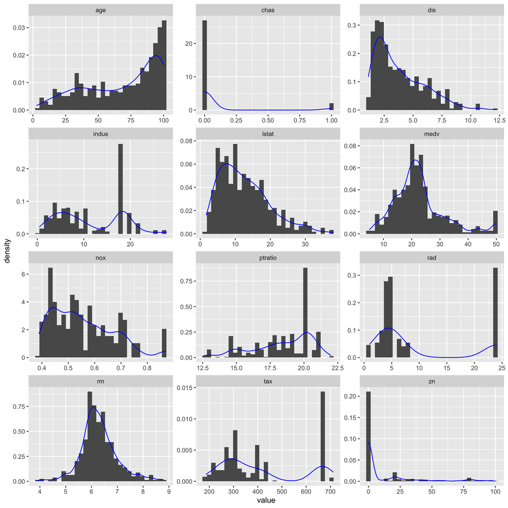

The distribution profiles show the prevalence of kurtosis, specifically right skew in variables `dis`, `lstat`, `nox`, `rm`, `zn`, and left skew in `age` and `ptratio`. These deviations from a traditional normal distribution can be problematic for linear regression assumptions, and thus we might need to transform the data. The feature `chas` is binary, as it only assumes values of `0` or `1`. Furthermore, the features `tax`, `rad`, and possibly `indus` appear bimodal. Bimodal features in a dataset are both problematic and interesting and potentially an area of opportunity and exploration. Bimodal data suggests that there are possibly two different groups or classes within the feature.

Bimodal features are extremely interesting in classification tasks, as they could indicate overlapping but separate distributions for each class, which could provide powerful predictive power in a model.

While we don’t tackle feature engineering in this analysis, if we were performing a more in-depth analysis, we could leverage the package, `mixtools` (see R Vignette). This package helps regress *mixed models* where data can be subdivided into subgroups.

Here is a quick example showing a possible mix within `indis`:

```
## number of iterations= 8
```

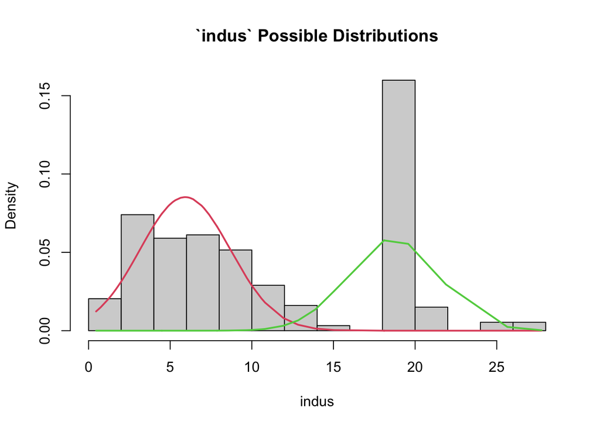

Lastly, several features have both a distribution along with a high number of values at an extreme. However, based on the feature meanings and provided information, there is no reason to believe that any of these extreme values are mistakes, data errors, or otherwise inexplicable. As such, we will not remove the extreme values, as they represent valuable data and could be predictive of the target.

### Boxplots

In addition to creating histogram distributions, we also elected to use box-plots to get an idea of the spread of each variable.

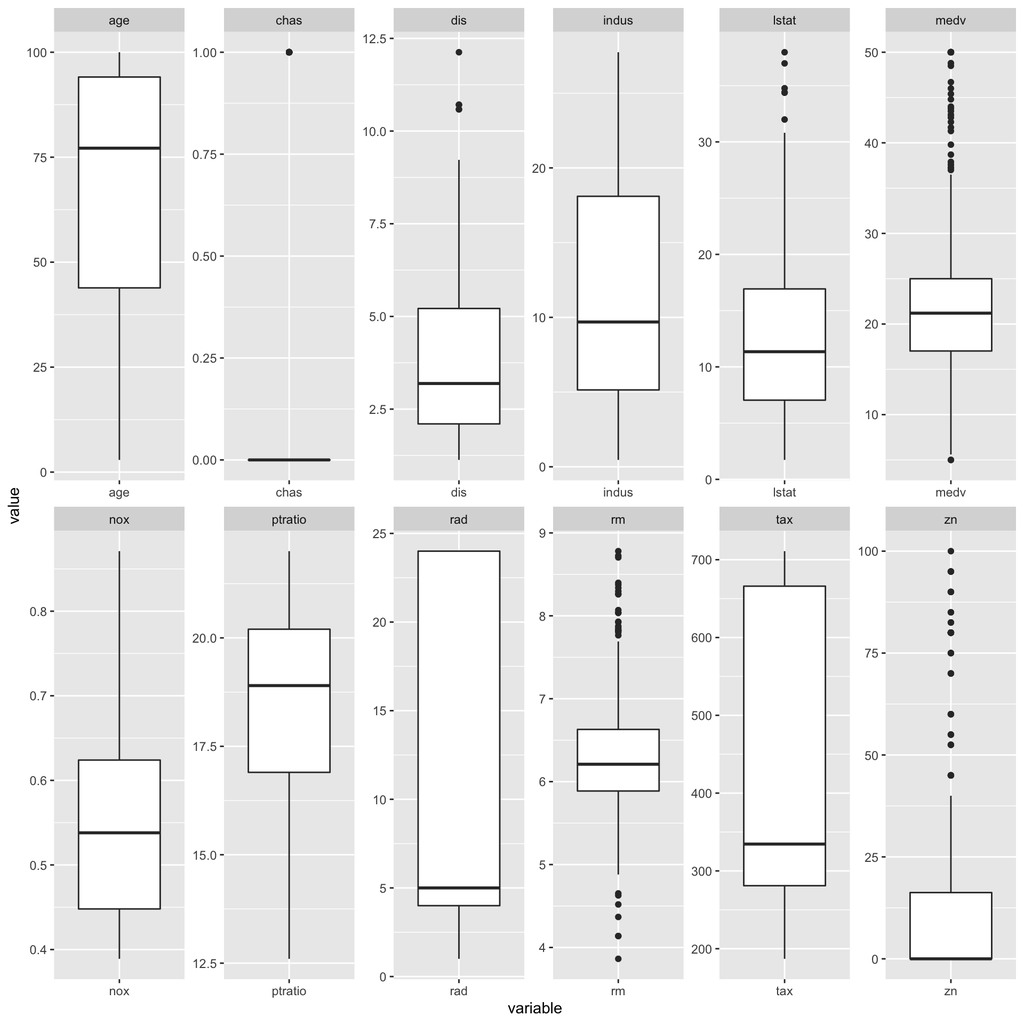

The box-plots reveal significant outliers that may need to be imputed if necessary.

### Variable Plots

Finally, we generate scatter plots of each variable versus the target variable to get an idea of the relationship between them.

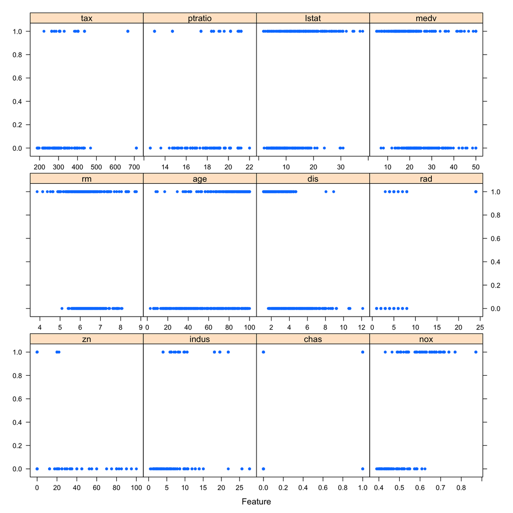

Although it does not appear that any one feature clearly distinguishes the two target values, there are many features that appear to have some significant correlation with the target, including `lstat`, `age`, `dis`, `zn`, and `nox`. This indicates that our data may be predictive and the model building process is likely to model an actual relationship rather than just overfitting to the quirks of the training data.

### Missing Data

Fortunately, we see no NAs, or missing data in the provided training dataset.

```
##    values     ind
## 1       0      zn
## 2       0   indus
## 3       0    chas
## 4       0     nox
## 5       0      rm
## 6       0     age
## 7       0     dis
## 8       0     rad
## 9       0     tax
## 10      0 ptratio
## 11      0   lstat
## 12      0    medv
## 13      0  target
```

### Handle Outliers

As mentioned above, for this task we chose not to remove outliers as there was no reason to believe that any of the values were in error.

### Feature-Target Correlations

```
##         values     ind
## 1   0.72610622     nox
## 2   0.63010625     age
## 3   0.62810492     rad
## 4   0.61111331     tax
## 5   0.60485074   indus
## 6   0.46912702   lstat
## 7   0.25084892 ptratio
## 8   0.08004187    chas
## 9  -0.15255334      rm
## 10 -0.27055071    medv
## 11 -0.43168176      zn
## 12 -0.61867312     dis
```

`dis`, `zn`, and `medv` all have a negative correlation to `target`, indicating that more distant areas with large lot sizes and high median home values are less likely to be high crime, all of which seem sensible.

### Multicollinearity

One problem that can occur with multi-variable regression is a correlation between variables, called Multicollinearity. A quick check is to run correlations between variables.

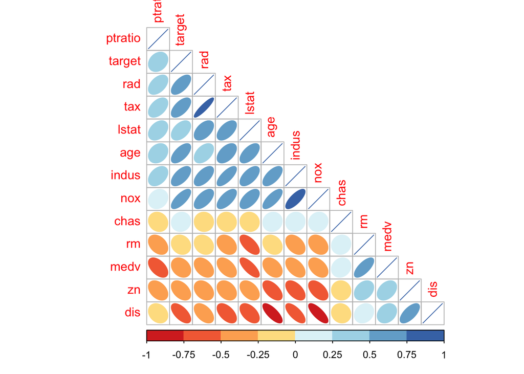

We can see that some variables are highly correlated with one another, such as `tax` and `rad`, with a correlation between .75 and 1. When we start considering features for our models, we’ll need to account for the correlations between features and avoid including pairs with strong correlations.

As a note, this dataset is challenging as many of the predictive features go hand-in-hand with other features and multicolinearity will be a problem. Home size, price, age, and distance from employment centers could all potentially be related, so it makes sense to see some collinearity in the features.

## 2. Data Preparation

To summarize our data preparation and exploration, we can distinguish our findings into a few categories below:

### Removed Fields

All the predictor variables have no missing values and show no indication of incomplete or incorrect data. As such, we have kept all the fields.

### Missing Values

The data had no missing values to remove.

### Outliers

No outliers were removed as all values seemed reasonable.

### Transform non-normal variables

Finally, as mentioned earlier in our data exploration, and our findings from our histogram plots, we can see that some of our variables are highly skewed. To address this, we decided to perform some transformations to make them more normally distributed. Here are some plots to demonstrate the changes in distributions before and after the transformations:

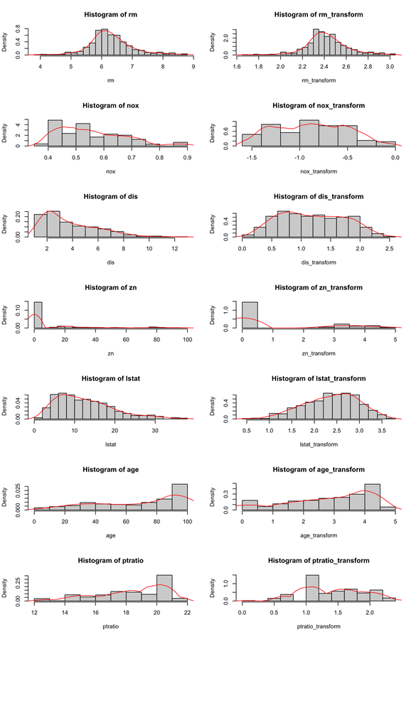

### Finalizing the dataset for model building

With our transformations complete, we can now add these into our `clean_df` dataframe and continue on to build our models.

## 3. Build Models

*Using the training data, build at least three different binary logistic regression models, using different variables (or the same variables with different transformations). You may select the variables manually, use an approach such as Forward or Stepwise, use a different approach, or use a combination of techniques. Describe the techniques you used. If you manually selected a variable for inclusion into the model or exclusion into the model, indicate why this was done.* *Be sure to explain how you can make inferences from the model, as well as discuss other relevant model output. Discuss the coefficients in the models, do they make sense? Are you keeping the model even though it is counter-intuitive? Why? The boss needs to know.*

### Model-building methodology

With a solid understanding of our dataset at this point, and with our data cleaned, we can now start to build out some of our binary logistic regression models.

First, we decided to split our cleaned dataset into a training and testing set (80% training, 20% testing). This was necessary as the provided holdout evaluation dataset doesn’t provide `target` values so we cannot measure our model performance against that dataset.

#### Model #1 *(Raw Features)*

Using our training dataset, we decided to run a binary logistic regression model that included all non-transformed features that we hadn’t removed following our data cleaning process mentioned above.

```
##
## Call:
## glm(formula = target ~ zn + indus + chas + nox + rm + age + dis +
##     rad + tax + ptratio + lstat + medv, family = binomial, data = cleaneddftraining)
##
## Deviance Residuals:
##      Min        1Q    Median        3Q       Max
## -1.92931  -0.02942  -0.00006   0.00020   2.99849
##
## Coefficients:
##               Estimate Std. Error z value Pr(>|z|)
## (Intercept) -61.876805  11.104609  -5.572 2.52e-08 ***
## zn           -0.097157   0.054388  -1.786 0.074042 .
## indus        -0.092162   0.064947  -1.419 0.155888
## chas          1.442852   1.001954   1.440 0.149856
## nox          68.689102  13.055167   5.261 1.43e-07 ***
## rm           -1.111323   1.057127  -1.051 0.293136
## age           0.085584   0.022193   3.856 0.000115 ***
## dis           1.258497   0.374901   3.357 0.000788 ***
## rad           0.900122   0.239910   3.752 0.000175 ***
## tax          -0.006122   0.004098  -1.494 0.135217
## ptratio       0.665643   0.198810   3.348 0.000814 ***
## lstat        -0.001007   0.068152  -0.015 0.988210
## medv          0.293953   0.103956   2.828 0.004689 **
## ---
## Signif. codes:  0 '***' 0.001 '**' 0.01 '*' 0.05 '.' 0.1 ' ' 1
##
## (Dispersion parameter for binomial family taken to be 1)
##
##     Null deviance: 516.63  on 372  degrees of freedom
## Residual deviance: 110.68  on 360  degrees of freedom
## AIC: 136.68
##
## Number of Fisher Scoring iterations: 9
```

We also calculated *VIF scores* to measure the effects of collinearity as well as variable importance:

```
## [1] "VIF scores of predictors"
```

```
##        zn     indus      chas       nox        rm       age       dis       rad
##  2.055550  2.683933  1.353039  5.573427  7.313187  3.189662  4.971248  2.424854
##       tax   ptratio     lstat      medv
##  2.289799  3.203721  2.635193 11.683660
```

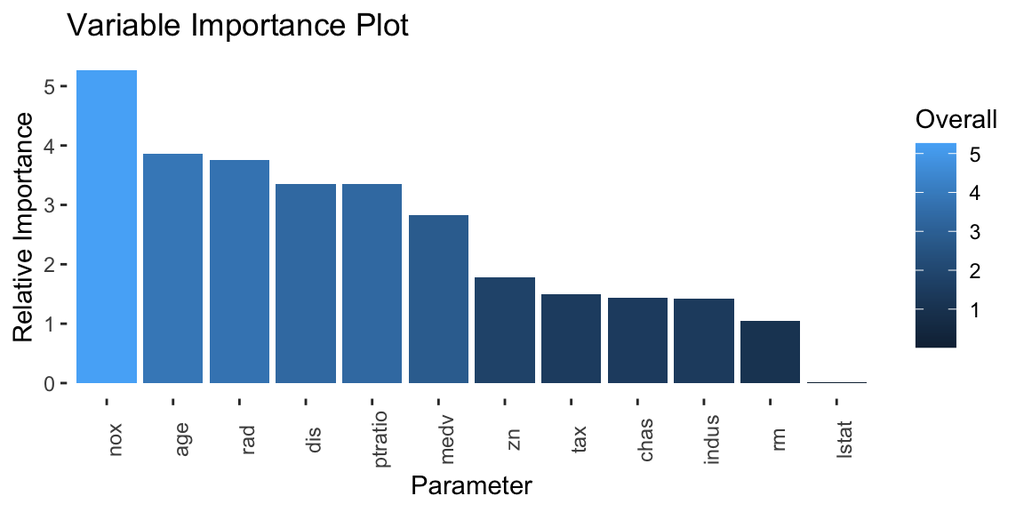

#### Model #2 *(Transformed Features)*

*Model #2* was built using our transformed features.

```
##
## Call:
## glm(formula = target ~ zn_transform + indus + chas + nox_transform +
##     rm_transform + age_transform + dis_transform + rad + tax +
##     ptratio_transform + lstat_transform + medv, family = binomial,
##     data = cleaneddftraining)
##
## Deviance Residuals:
##     Min       1Q   Median       3Q      Max
## -1.9363  -0.0467  -0.0005   0.0002   3.3342
##
## Coefficients:
##                    Estimate Std. Error z value Pr(>|z|)
## (Intercept)       19.648555  11.227065   1.750 0.080100 .
## zn_transform      -0.481877   0.337480  -1.428 0.153330
## indus             -0.026942   0.068561  -0.393 0.694340
## chas               1.226179   0.994598   1.233 0.217636
## nox_transform     17.439569   3.229450   5.400 6.66e-08 ***
## rm_transform      -2.864549   3.657480  -0.783 0.433508
## age_transform     -1.533715   0.390108  -3.932 8.44e-05 ***
## dis_transform      3.951566   1.330350   2.970 0.002975 **
## rad                0.986357   0.261550   3.771 0.000162 ***
## tax               -0.006789   0.004322  -1.571 0.116223
## ptratio_transform -2.828343   0.802360  -3.525 0.000423 ***
## lstat_transform   -0.754703   1.008646  -0.748 0.454319
## medv               0.219507   0.086708   2.532 0.011355 *
## ---
## Signif. codes:  0 '***' 0.001 '**' 0.01 '*' 0.05 '.' 0.1 ' ' 1
##
## (Dispersion parameter for binomial family taken to be 1)
##
##     Null deviance: 516.63  on 372  degrees of freedom
## Residual deviance: 105.74  on 360  degrees of freedom
## AIC: 131.74
##
## Number of Fisher Scoring iterations: 9
```

We also calculated *VIF scores* to measure the effects of collinearity as well as variable importance:

```
## [1] "VIF scores of predictors"
```

```
##      zn_transform             indus              chas     nox_transform
##          1.783127          2.722927          1.362322          3.633686
##      rm_transform     age_transform     dis_transform               rad
##          5.551059          2.350723          3.520485          2.531822
##               tax ptratio_transform   lstat_transform              medv
##          2.506246          2.755768          3.769478          6.851934
```

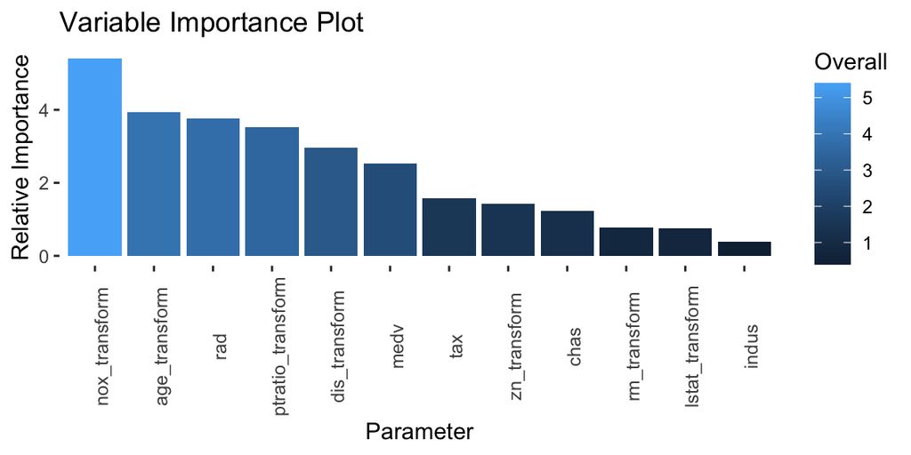

#### Model #3 *(Stepwise-AIC on Model #1)*

In our next model, we used a *Stepwise AIC* on *Model #1* (our model with non-transformed features) to pick which features were most relevant.

```
##
## Call:
## glm(formula = target ~ zn + indus + chas + nox + age + dis +
##     rad + tax + ptratio + medv, family = binomial, data = cleaneddftraining)
##
## Deviance Residuals:
##      Min        1Q    Median        3Q       Max
## -2.01736  -0.04218  -0.00012   0.00045   3.04078
##
## Coefficients:
##               Estimate Std. Error z value Pr(>|z|)
## (Intercept) -61.579380  10.924258  -5.637 1.73e-08 ***
## zn           -0.099274   0.053491  -1.856 0.063470 .
## indus        -0.087984   0.064947  -1.355 0.175514
## chas          1.580819   1.004001   1.575 0.115368
## nox          65.295329  12.193437   5.355 8.56e-08 ***
## age           0.074673   0.017516   4.263 2.02e-05 ***
## dis           1.170570   0.353153   3.315 0.000918 ***
## rad           0.820831   0.225401   3.642 0.000271 ***
## tax          -0.005837   0.004020  -1.452 0.146532
## ptratio       0.570151   0.168084   3.392 0.000694 ***
## medv          0.196640   0.055583   3.538 0.000404 ***
## ---
## Signif. codes:  0 '***' 0.001 '**' 0.01 '*' 0.05 '.' 0.1 ' ' 1
##
## (Dispersion parameter for binomial family taken to be 1)
##
##     Null deviance: 516.63  on 372  degrees of freedom
## Residual deviance: 112.10  on 362  degrees of freedom
## AIC: 134.1
##
## Number of Fisher Scoring iterations: 9
```

We also calculated *VIF scores* to measure the effects of collinearity as well as variable importance:

```
## [1] "VIF scores of predictors"
```

```
##       zn    indus     chas      nox      age      dis      rad      tax
## 1.989664 2.702260 1.256644 4.859144 2.018329 4.508705 2.104971 2.245591
##  ptratio     medv
## 2.327607 3.253767
```

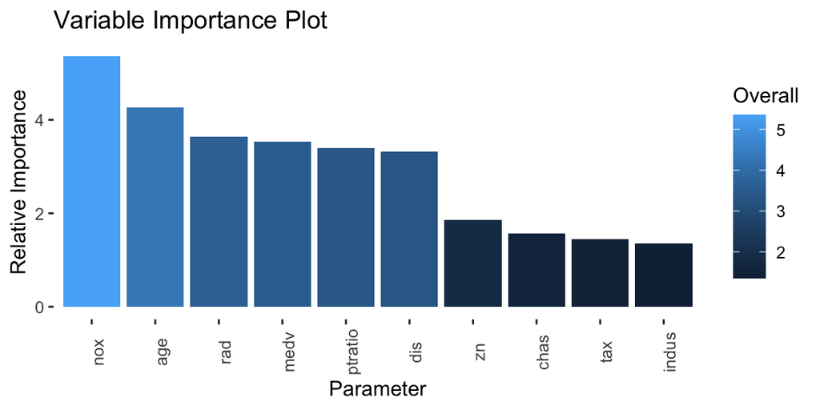

#### Model #4 *(Stepwise-AIC on Model #2)*

In our final model, we applied *Stepwise AIC* on *Model #2* (our model with transformed features) to pick which features were most relevant.

```
##
## Call:
## glm(formula = target ~ zn_transform + nox_transform + age_transform +
##     dis_transform + rad + tax + ptratio_transform + medv, family = binomial,
##     data = cleaneddftraining)
##
## Deviance Residuals:
##     Min       1Q   Median       3Q      Max
## -1.7907  -0.0368  -0.0006   0.0001   3.3219
##
## Coefficients:
##                    Estimate Std. Error z value Pr(>|z|)
## (Intercept)        9.798986   2.917739   3.358 0.000784 ***
## zn_transform      -0.644205   0.319078  -2.019 0.043492 *
## nox_transform     16.352106   3.045619   5.369 7.91e-08 ***
## age_transform     -1.453228   0.325122  -4.470 7.83e-06 ***
## dis_transform      4.036422   1.281617   3.149 0.001636 **
## rad                1.021022   0.230145   4.436 9.15e-06 ***
## tax               -0.007794   0.003903  -1.997 0.045819 *
## ptratio_transform -2.478915   0.710827  -3.487 0.000488 ***
## medv               0.195979   0.055413   3.537 0.000405 ***
## ---
## Signif. codes:  0 '***' 0.001 '**' 0.01 '*' 0.05 '.' 0.1 ' ' 1
##
## (Dispersion parameter for binomial family taken to be 1)
##
##     Null deviance: 516.63  on 372  degrees of freedom
## Residual deviance: 108.13  on 364  degrees of freedom
## AIC: 126.13
##
## Number of Fisher Scoring iterations: 9
```

We also calculated *VIF scores* to measure the effects of collinearity as well as variable importance:

```
## [1] "VIF scores of predictors"
```

```
##      zn_transform     nox_transform     age_transform     dis_transform
##          1.570677          3.366213          1.725178          3.408731
##               rad               tax ptratio_transform              medv
##          2.000213          2.087589          2.164370          2.679912
```

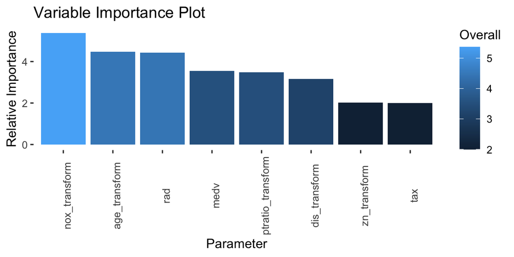

### Examining our model coefficients

Throughout our model-building process, we noticed that many of our model outputs yielded a few coefficient values that seemed to contradict our initial estimates. For instance, in *Model #1*:

**Positive values for coefficients that we’d expect to be negative**

- **age** - logically we thought that the higher the proportion of owner-occupied units built prior to 1940 would lead to a lower crime rate (historic homes with more property value)
- **dis** - logically we thought that the higher the weighted mean value of distance to five Boston employment centers, the lower the crime rate (areas farther from employment centers indicated there is less of a need for them – higher rates of employment)
- **medv** - logically we thought the higher the median value of owner-occupied homes in $1000s would lead to a lower crime rate

## 4. Model Selection & Analysis

*For the binary logistic regression model, will you use a metric such as log-likelihood, AIC, ROC curve, etc.? Using the training data set, evaluate the binary logistic regression model based on (a) accuracy, (b) classification error rate, (c) precision, (d) sensitivity, (e) specificity, (f) F1 score, (g) AUC, and (h) confusion matrix. Make predictions using the evaluation data set.*

### Confusion Matrices

*Model #1* Confusion Matrix:

```
## Confusion Matrix and Statistics
##
##           Reference
## Prediction  0  1
##          0 42 11
##          1  2 38
##
##                Accuracy : 0.8602
##                  95% CI : (0.7728, 0.9234)
##     No Information Rate : 0.5269
##     P-Value [Acc > NIR] : 1.023e-11
##
##                   Kappa : 0.7225
##
##  Mcnemar's Test P-Value : 0.0265
##
##             Sensitivity : 0.7755
##             Specificity : 0.9545
##          Pos Pred Value : 0.9500
##          Neg Pred Value : 0.7925
##              Prevalence : 0.5269
##          Detection Rate : 0.4086
##    Detection Prevalence : 0.4301
##       Balanced Accuracy : 0.8650
##
##        'Positive' Class : 1
##
```

*Model #2* Confusion Matrix:

```
## Confusion Matrix and Statistics
##
##           Reference
## Prediction  0  1
##          0 40 11
##          1  4 38
##
##                Accuracy : 0.8387
##                  95% CI : (0.748, 0.9068)
##     No Information Rate : 0.5269
##     P-Value [Acc > NIR] : 2.581e-10
##
##                   Kappa : 0.6791
##
##  Mcnemar's Test P-Value : 0.1213
##
##             Sensitivity : 0.7755
##             Specificity : 0.9091
##          Pos Pred Value : 0.9048
##          Neg Pred Value : 0.7843
##              Prevalence : 0.5269
##          Detection Rate : 0.4086
##    Detection Prevalence : 0.4516
##       Balanced Accuracy : 0.8423
##
##        'Positive' Class : 1
##
```

*Model #3* Confusion Matrix:

```
## Confusion Matrix and Statistics
##
##           Reference
## Prediction  0  1
##          0 42 12
##          1  2 37
##
##                Accuracy : 0.8495
##                  95% CI : (0.7603, 0.9152)
##     No Information Rate : 0.5269
##     P-Value [Acc > NIR] : 5.349e-11
##
##                   Kappa : 0.7015
##
##  Mcnemar's Test P-Value : 0.01616
##
##             Sensitivity : 0.7551
##             Specificity : 0.9545
##          Pos Pred Value : 0.9487
##          Neg Pred Value : 0.7778
##              Prevalence : 0.5269
##          Detection Rate : 0.3978
##    Detection Prevalence : 0.4194
##       Balanced Accuracy : 0.8548
##
##        'Positive' Class : 1
##
```

*Model #4* Confusion Matrix:

```
## Confusion Matrix and Statistics
##
##           Reference
## Prediction  0  1
##          0 40 11
##          1  4 38
##
##                Accuracy : 0.8387
##                  95% CI : (0.748, 0.9068)
##     No Information Rate : 0.5269
##     P-Value [Acc > NIR] : 2.581e-10
##
##                   Kappa : 0.6791
##
##  Mcnemar's Test P-Value : 0.1213
##
##             Sensitivity : 0.7755
##             Specificity : 0.9091
##          Pos Pred Value : 0.9048
##          Neg Pred Value : 0.7843
##              Prevalence : 0.5269
##          Detection Rate : 0.4086
##    Detection Prevalence : 0.4516
##       Balanced Accuracy : 0.8423
##
##        'Positive' Class : 1
##
```

### ROC Curves

A Comparison of ROC Curves for each model, *Model #1* … *Model #4*:

```
## [1] "Model #1 ROC Curve"
```

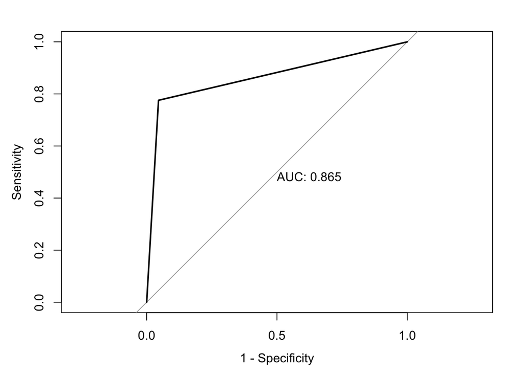

```
##
## Call:
## roc.default(response = cleaneddftesting[["target"]], predictor = cleaneddftesting[["model1"]],     plot = TRUE, legacy.axes = TRUE, print.auc = TRUE)
##
## Data: cleaneddftesting[["model1"]] in 44 controls (cleaneddftesting[["target"]] 0) < 49 cases (cleaneddftesting[["target"]] 1).
## Area under the curve: 0.865
```

```
## [1] "Model #2 ROC Curve"
```

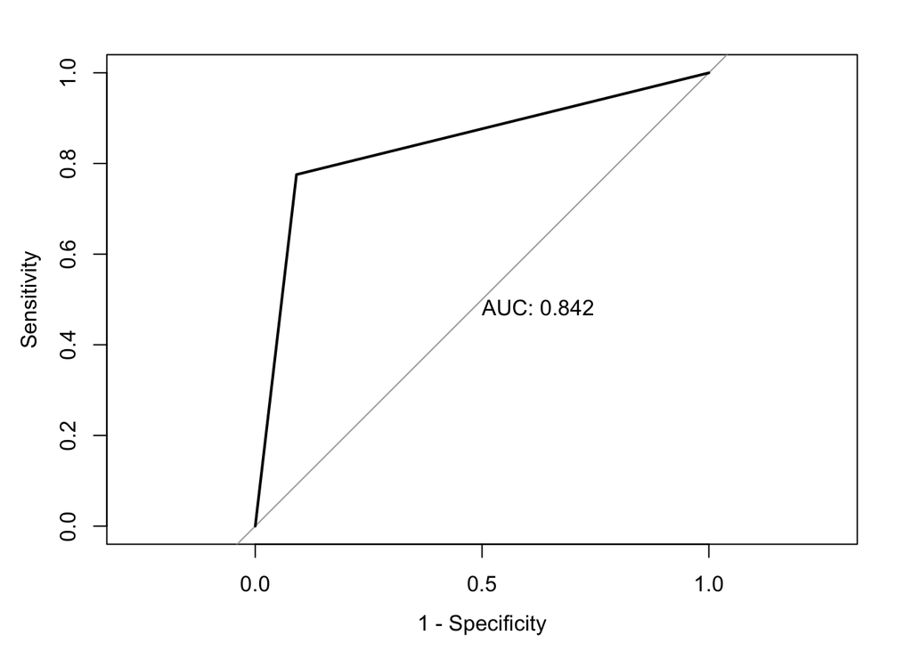

```
##
## Call:
## roc.default(response = cleaneddftesting[["target"]], predictor = cleaneddftesting[["model2"]],     plot = TRUE, legacy.axes = TRUE, print.auc = TRUE)
##
## Data: cleaneddftesting[["model2"]] in 44 controls (cleaneddftesting[["target"]] 0) < 49 cases (cleaneddftesting[["target"]] 1).
## Area under the curve: 0.8423
```

```
## [1] "Model #3 ROC Curve"
```

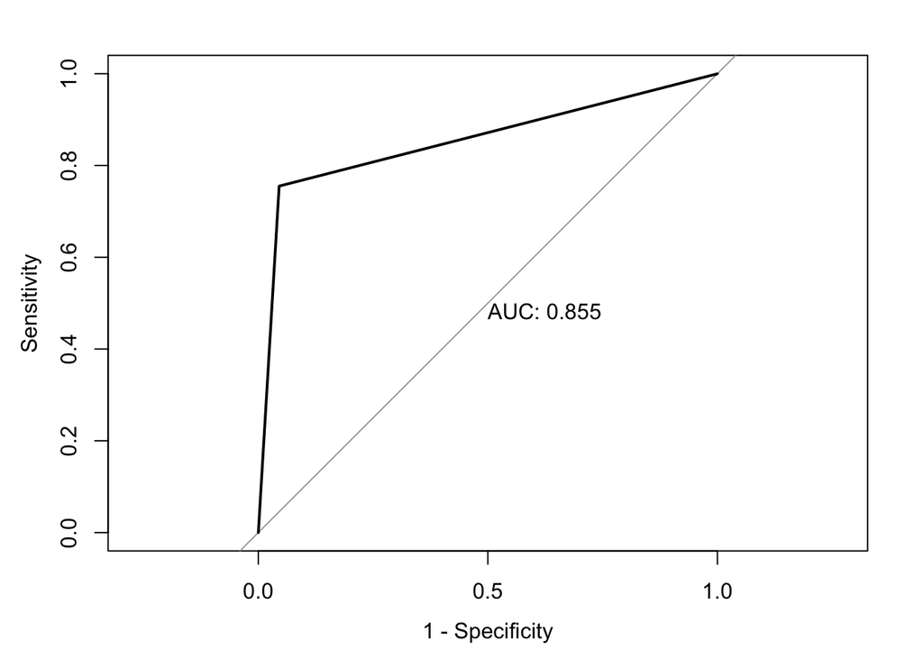

```
##
## Call:
## roc.default(response = cleaneddftesting[["target"]], predictor = cleaneddftesting[["model3"]],     plot = TRUE, legacy.axes = TRUE, print.auc = TRUE)
##
## Data: cleaneddftesting[["model3"]] in 44 controls (cleaneddftesting[["target"]] 0) < 49 cases (cleaneddftesting[["target"]] 1).
## Area under the curve: 0.8548
```

```
## [1] "Model #4 ROC Curve"
```

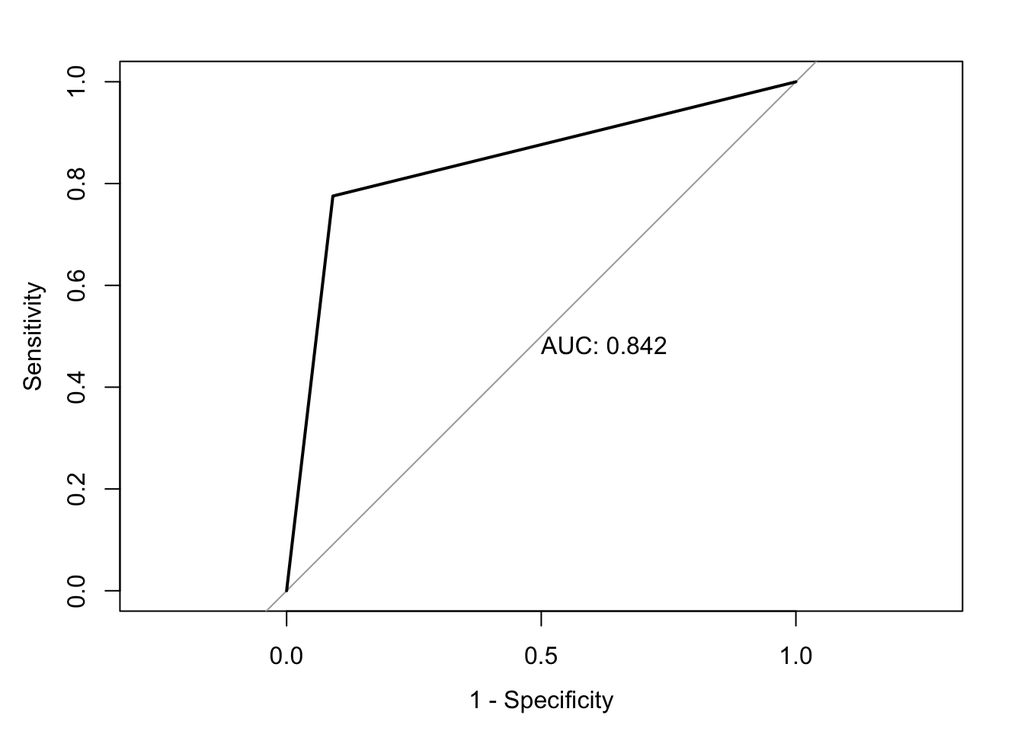

```
##
## Call:
## roc.default(response = cleaneddftesting[["target"]], predictor = cleaneddftesting[["model4"]],     plot = TRUE, legacy.axes = TRUE, print.auc = TRUE)
##
## Data: cleaneddftesting[["model4"]] in 44 controls (cleaneddftesting[["target"]] 0) < 49 cases (cleaneddftesting[["target"]] 1).
## Area under the curve: 0.8423
```

### Model Performance Summary

[output not shown]

The above table summarizes the *accuracy*, *F-statistic*, *deviance*, *$R^2$* (McFaden) and *AIC* of all of our models.

In terms of absolute metrics:

*Model #1* had the highest *accuracy* and *F-statistic*. *Model #2* had the highest *$R^2$* (Mcfaden psuedo) and lowest *deviance*. *Model #4* had the lowest *AIC.*

Recall that *Model #1* consisted of the untransformed data. *Model #2* was transformed data. *Model #3* and *Model #4* were *Stepwise AIC* optimizations of said models.

When looking at *Model #1* vs *Model #2*–while Model #1 had higher accuracy, and essentially the same F-statistics, Model #2 had lower *deviance* and *AIC*, and higher *$R^2$*. This shows that *Model #2* was of higher quality and fit, with less error than *Model #1*, albeit slightly less accurate.

Looking at *Model #1* vs *Model #3* we see that *Model #1* had a high *Accuracy*,* F-statistic*, lower* deviance*, and higher* $R^2$* than *Model #3*. *Model #3* had a lower *AIC*–but this is to be expected as it’s an optimized *AIC* of *Model #1*. This result is interesting as it shows that while *Model #3* is a higher quality (lower *AIC*), it doesn’t have stronger predictive power (*$R^2$* and *deviation.*)

*Model #2* and *Model #4* shared the same *accuracy* and *F1*, and differed slightly in *deviance*, *$R^2$*, and *AIC*–this was expected since *Model #4* is a *Stepwise-AIC* optimization.

Finally comparing *Model #3* and *Model #4*, we can make the same generalizations from *Model #1* and *Model #2*, since both models are the basis–*Model #4* was of better quality/fit with less deviation, albeit slightly less accurate.

## Model of choice

Based on all of our models we gave the edge to* Model #2* and *Model #4*, given that they fit the data (Higher *$R^2$*, lower *AIC*, lower *deviance*) better than their counterparts.

## Predictions

We apply **Model #4** to the holdout evaluation set to predict the targets for these 40 instances. We have saved these predictions as csv in the file `eval_predictions.csv`.

Source code: https://github.com/djlofland/DS621_F2020_Group3/tree/master/Homework_3/eval_predictions.csv

```
##  1  2  3  4  5  6  7  8  9 10 11 12 13 14 15 16 17 18 19 20 21 22 23 24 25 26
##  0  1  1  1  0  0  0  0  0  0  0  0  1  1  1  0  0  1  0  0  0  0  0  0  0  1
## 27 28 29 30 31 32 33 34 35 36 37 38 39 40
##  0  1  1  1  1  1  1  1  1  1  1  1  1  1
```

## References

- A Modern Approach to Regression with R: Simon Sheather
- Linear Models with R: Julian Faraway.
- R package vignette, [mixtools: An R Package for Analyzing Finite Mixture Models](https://cran.r-project.org/web/packages/mixtools/vignettes/mixtools.pdf)
- [7 Classic OLS assumptions](https://statisticsbyjim.com/regression/ols-linear-regression-assumptions/)
- [Detecting Multicolinearity with VIF](https://online.stat.psu.edu/stat462/node/180/)

## Appendix

### A. Crime Dataset Columns

- [Group 3 HW 3 GitHub](https://github.com/djlofland/DS621_F2020_Group3/tree/master/Homework_3)

### R Code

```
# =====================================================================================
# Load Libraries and Define Helper functions
# =====================================================================================

library(MASS)
library(rpart.plot)
library(ggplot2)
library(ggfortify)
library(gridExtra)
library(forecast)
library(fpp2)
library(fma)
library(kableExtra)
library(e1071)
library(mlbench)
library(ggcorrplot)
library(DataExplorer)
library(timeDate)
library(caret)
library(GGally)
library(corrplot)
library(RColorBrewer)
library(tibble)
library(tidyr)
library(tidyverse)
library(dplyr)
library(reshape2)
library(mixtools)
library(tidymodels)
library(ggpmisc)
library(regclass)
library(pROC)

#' Print a side-by-side Histogram and QQPlot of Residuals
#'
#' @param model A model
#' @examples
#' residPlot(myModel)
#' @return null
#' @export
```

[output cut: 420 more lines]

```
                        ))

is.na(df_eval) <- sapply(df_eval, is.infinite)


# =====================================================================================
# Making predictions on evaluation set with Model #4, printing to csv
# =====================================================================================

eval_data <- df_eval %>% select(c(zn_transform, indus, chas, nox_transform, rm_transform, age_transform, dis_transform, rad, tax, ptratio_transform, lstat_transform, medv))
predictions <- ifelse(predict(model4, eval_data, type = "link") > 0.5, 1, 0)
df_eval['target'] <- predictions

write.csv(df_eval, 'eval_predictions.csv', row.names=F)
predictions
```